# Lab 9: Sentiment Analysis

Shuying Yu

3/3/2022

# Get The Hobbit

```r
hobbit_text <- pdf_text(here::here('data', 'the-hobbit.pdf'))

hobbit_p34 <- hobbit_text[34]
```

# Break down into pages and lines

```r
hobbit_lines <- data.frame(hobbit_text) %>%
  mutate(page = 1:n()) %>%
  mutate(text_full = str_split(hobbit_text, pattern = '\\n')) %>%
  unnest(text_full) %>%

  #Get rid of extra white space
  mutate(text_full = str_trim(text_full))
```

# Do some tidying

Chapter 1 starts on line 138, so drop everything before it

```r
hobbit_chapts <- hobbit_lines %>%

  #Remove row
  slice(-(1:137)) %>%

  #Create chapter column
  mutate(chapter = ifelse(str_detect(text_full, "Chapter"), text_full, NA)) %>%

  #Fill the NAs with everything before it (chapter number)
  fill(chapter, .direction = 'down') %>%

  #Take chapter column, separate the chapter work and the number
  separate(col = chapter, into = c("ch", "no"), sep = " ") %>%

  #Change roman numeral as a factor and write as a latin number
  mutate(chapter = as.numeric(as.roman(no)))
```

# Do some word counts by chapter

Tokenize text, break down text into tokens of choosing

We define token as individual words (others can sort by are sentences, *n*grams/bigrams, different ways of breaking them down)

```r
hobbit_words <- hobbit_chapts %>%

  #Tokenize by words, drops punctuation
  unnest_tokens(word, text_full, token = "words") %>%

  #Remove hobbit text
  select(-hobbit_text)




#Get total word count for each word by chapter
hobbit_wordcount <- hobbit_words %>%
  count(chapter, word)

#The, and, etc are stop words
```

# Remove stop words

We can remove stop words

```r
#Tidyverse considers these as stop words, 1149 stop words
head(stop_words)
```

```
## # A tibble: 6 x 2
##   word      lexicon
##   <chr>     <chr>
## 1 a         SMART
## 2 a's       SMART
## 3 able      SMART
## 4 about     SMART
## 5 above     SMART
## 6 according SMART
```

```r
#Create one without stop words
hobbit_words_clean <- hobbit_words %>%

  #Start with hobbit_words, remove anything in df that i want to join
  anti_join(stop_words, by = 'word')
```

Then let’s try counting them again

```r
nonstop_counts <- hobbit_words_clean %>%
  count(chapter, word)
```

## Find the top 5 words from each chapter

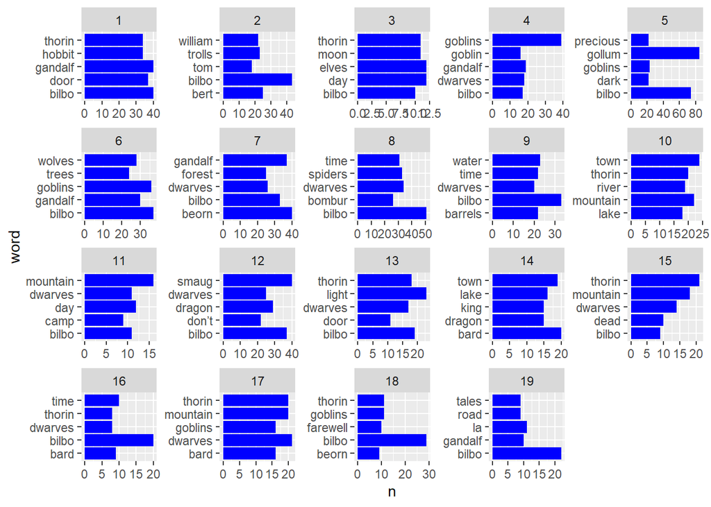

```r
#Top 5 words for each chapter
top_5_words <- nonstop_counts %>%
  group_by(chapter) %>%
  arrange(-n) %>%
  slice(1:5) %>%
  ungroup()

#Make some graphs:
ggplot(data = top_5_words, aes(x = n, y = word)) +
  geom_col(fill = "blue") +

  #Scales = free means we see relative amount of each chapter
  #Each scale associated with each chapter
  facet_wrap(~chapter, scales = "free")
```

## Word cloud for Chapter 1

Built into `ggwordcloud` package

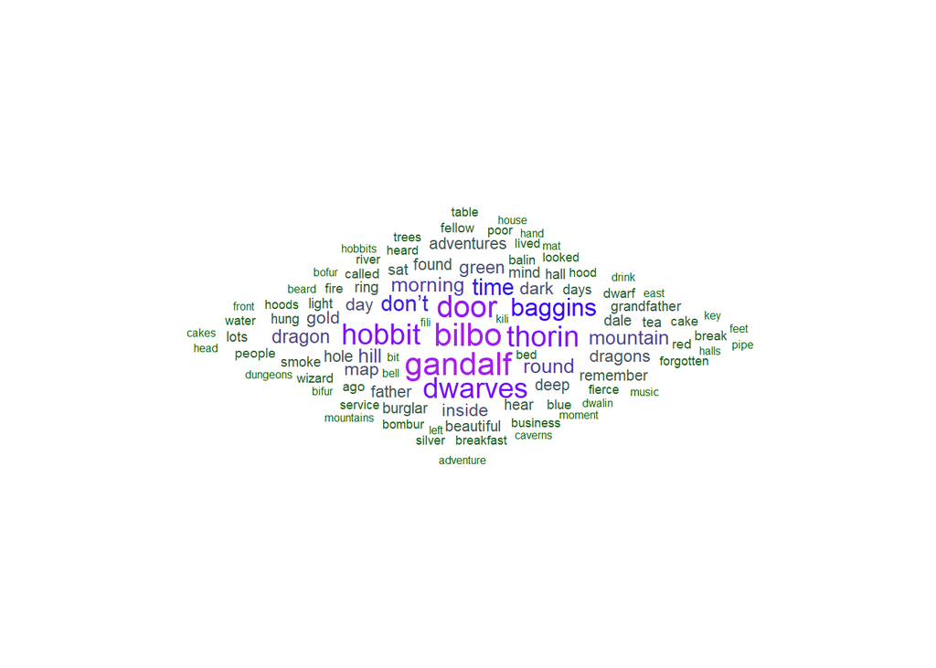

```r
ch1_top100 <- nonstop_counts %>%
  filter(chapter == 1) %>%

  #Arrange decending orders
  arrange(-n) %>%

  #Just keep top 100
  slice(1:100)


#Create word cloud plot
ch1_cloud <- ggplot(data = ch1_top100,
                    aes(label = word)) +

  #Define word cloud
  #Color and size changes based on n
  geom_text_wordcloud(aes(color = n, size = n),

                      #Change cloud based on shape
                      shape = "diamond") +

  #Scale sizes of words
  scale_size_area(max_size = 6) +

  #Make scale for color
  scale_color_gradientn(colors = c("darkgreen","blue","purple")) +

  #Change theme
  theme_minimal()



#Plot it
ch1_cloud
```

# Sentiment Analysis

Each word associated with emotional weight, positive or negative association.

The three general-purpose lexicons are

- AFINN from Finn Årup Nielsen, (positive and negative, weighted by strength of positive or negative association)
- bing from Bing Liu and collaborators, and (positive or negative, or 0)
- nrc from Saif Mohammad and Peter Turney (word emotion association lexicon, one of 8 emotions that the word is associated with)

“afinn”: Words ranked from -5 (very negative) to +5 (very positive)

```r
#Get sentiment data from tidyverse package
#Tibble of ~2500 words
#get_sentiments(lexicon = "afinn")

#Let's look at the pretty positive words:
afinn_pos <- get_sentiments("afinn") %>%

  #Looks at 3,4,5 values
  filter(value %in% c(3,4,5))
```

For comparison, check out the bing lexicon:

```r
#get_sentiments(lexicon = "bing")
```

Now nrc:

```r
#get_sentiments(lexicon = "nrc")
```

## Sentiment analysis with afinn:

First, bind words in `hobbit_nonstop_words` to `afinn` lexicon:

```r
hobbit_afinn <- hobbit_words_clean %>%

  #Keep instance of first df that match 2nd df
  #Keep rows that match between the two
  inner_join(get_sentiments("afinn"), by = 'word')
```

Let’s find some counts (by sentiment ranking):

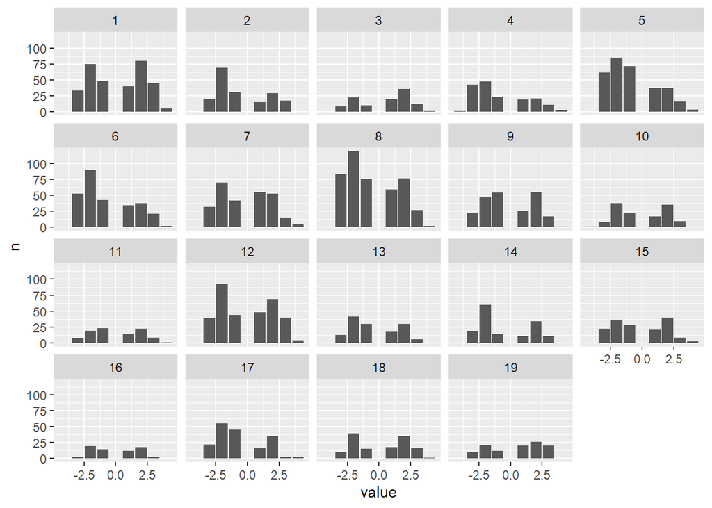

```r
#Howmany times a value shows up for each chapter
afinn_counts <- hobbit_afinn %>%
  count(chapter, value)

#Plot them
ggplot(data = afinn_counts, aes(x = value, y = n)) +
  geom_col() +
  facet_wrap(~chapter)
```

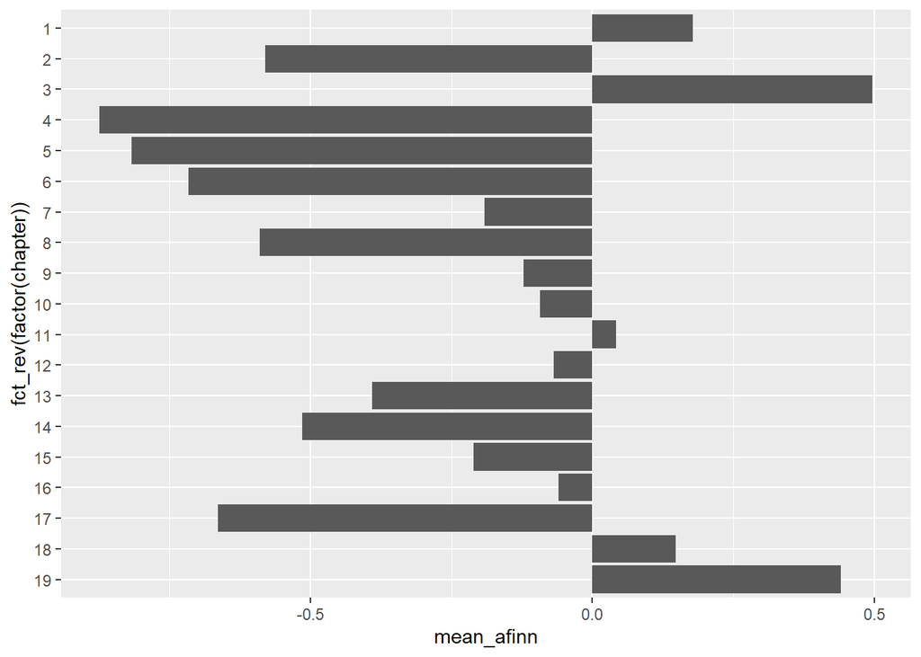

```r
#Find the mean afinn score by chapter:
afinn_means <- hobbit_afinn %>%
  group_by(chapter) %>%
  summarize(mean_afinn = mean(value))


#Plot it
ggplot(data = afinn_means,
       aes(x = fct_rev(factor(chapter)),
           y = mean_afinn)) +

  #Chapter 1 on top, so force as factor to be 1-20
           # y = fct_rev(as.factor(chapter)))) +
  geom_col() +

  coord_flip()
```